# Assignment 2

Tejaswini Sengaonkar

2023-08-20

## Question 1

Implement in.sorted(x, z) as a recursive function, where the argument x can be a vector of any length (just as for operator %in%).

```r
in.sorted <- function(x, z) {
  results <- logical(length(x))

  for (i in seq_along(x)) {
    found <- FALSE
    left <- 1
    right <- length(z)

    while (left <= right) {
      mid <- floor((left + right) / 2)

      if (x[i] == z[mid]) {
        found <- TRUE
        break
      } else if (x[i] < z[mid]) {
        right <- mid - 1
      } else {
        left <- mid + 1
      }
    }

    results[i] <- found
  }

  return(results)
}

set.seed(782)
z <- round(runif(10) * 10)
print(in.sorted(1:10, sort(z)))
```

```
##  [1] FALSE  TRUE  TRUE  TRUE  TRUE FALSE FALSE  TRUE FALSE  TRUE
```

```r
x2 = 1:100 * 1e4
z2 = sort(round(runif(1e6)*1e6))
in.sorted(x2, z2)
```

```
##   [1]  TRUE  TRUE  TRUE  TRUE  TRUE  TRUE  TRUE FALSE  TRUE  TRUE  TRUE FALSE
##  [13]  TRUE  TRUE  TRUE  TRUE FALSE  TRUE  TRUE FALSE  TRUE FALSE  TRUE FALSE
##  [25] FALSE  TRUE  TRUE FALSE  TRUE FALSE FALSE  TRUE FALSE  TRUE  TRUE  TRUE
##  [37]  TRUE  TRUE  TRUE FALSE  TRUE  TRUE  TRUE  TRUE FALSE  TRUE  TRUE  TRUE
##  [49] FALSE  TRUE FALSE FALSE  TRUE  TRUE  TRUE  TRUE  TRUE  TRUE  TRUE FALSE
##  [61]  TRUE FALSE FALSE  TRUE FALSE  TRUE  TRUE FALSE  TRUE FALSE  TRUE  TRUE
##  [73]  TRUE  TRUE  TRUE FALSE  TRUE  TRUE  TRUE FALSE  TRUE  TRUE  TRUE  TRUE
##  [85]  TRUE FALSE  TRUE  TRUE FALSE  TRUE FALSE FALSE  TRUE FALSE  TRUE  TRUE
##  [97] FALSE FALSE  TRUE FALSE
```

## Question 2

1. Implement the above mixture density function f , in an R function named dmix() which returns the density values at each of the points x1, . . . , xn. It has three arguments x, mu and p, for x = (x1, . . . , xn), μ and p, respectively. You may assume that mu and p have valid values and are of the same length when the function is called.

```r
dmix <- function(x, mu, p) {
  m <- length(mu)
  densities <- p * matrix(dnorm(rep(x, m), mean = rep(mu, each = length(x)), sd = 1), ncol = m)
  total_density <- rowSums(densities)
  return(total_density)
}

x1 <- -3:3
mu1 <- 0:1 * 3
p1 <- 2:1 / 3
density1 <- dmix(x1, mu1, p1)
density1
```

```
## [1] 0.002954568 0.017997980 0.161358426 0.135935326 0.179310805 0.179310805
## [7] 0.135935326
```

```r
x2 <- -5:5
mu2 <- -1:2 * 3
p2 <- 1:4 / 10
density2 <- dmix(x2, mu2, p2)
density2
```

```
##  [1] 0.005399691 0.048407528 0.120569054 0.112985877 0.102227536 0.042553339
##  [7] 0.053833985 0.064605413 0.122341794 0.112998963 0.102187684
```

2. Implement this algorithm in an R function named mem(x, mu, p), say, where the argu- ment x is a vector of any length, and mu and p are the parameters for the mixture, as in Part (a). Apply it to the two cases given in Part (a) and find the local maxima that the values in x are associated with. Make sure you have made use of vectorised computation as much as possible.

```r
mem <- function(x, mu, p) {
  max_iterations <- 1000
  tolerance <- 1e-6
  converged <- FALSE
  iter <- 0

  while (!converged && iter < max_iterations) {
    # Step 1
    component_densities <- matrix(dnorm(x, mean = rep(mu, each = length(x)), sd = 1), ncol = length(mu))
    f_x <- dmix(x, mu, p)
    q <- p * component_densities / f_x

    # Step 2
    new_x <- q %*% mu

    # Check for convergence
    if (all(abs(new_x - x) < tolerance)) {
      converged <- TRUE
    }

    x <- new_x
    iter <- iter + 1
  }

  return(x)
}

# Apply MEM algorithm
estimated_mode1 <- mem(x1, mu1, p1)
estimated_mode1
```

```
##            [,1]
## [1,] 0.01745727
## [2,] 0.08317226
## [3,] 0.01745727
## [4,] 0.08317242
## [5,] 0.01745727
## [6,] 2.98254273
## [7,] 2.91682758
```

```r
estimated_mode2 <- mem(x2, mu2, p2)
estimated_mode2
```

```
##              [,1]
##  [1,] -2.72011234
##  [2,] -2.98254252
##  [3,] -2.97633545
##  [4,] -2.97315054
##  [5,]  0.01831106
##  [6,]  0.16146620
##  [7,] -0.04078365
##  [8,]  2.95921588
##  [9,]  2.97290489
## [10,]  3.01831096
## [11,]  5.99147670
```

(c)Plot the two density functions for the two cases given in Part (a) and show in colour the local maxima computed in Part (b) on the curves.

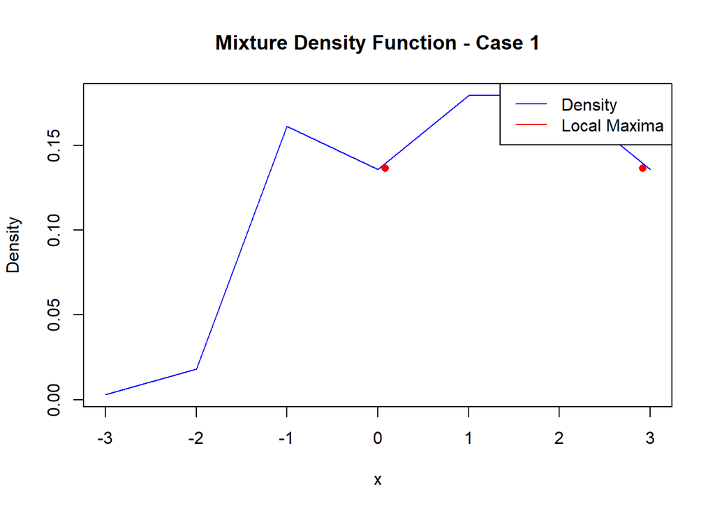

```r
plot(x1, density1, type = "l", col = "blue", xlab = "x", ylab = "Density", main = "Mixture Density Function - Case 1")
points(estimated_mode1, dmix(estimated_mode1, mu1, p1), col = "red", pch = 16)
legend("topright", legend = c("Density", "Local Maxima"), col = c("blue", "red"), lty = 1)
```

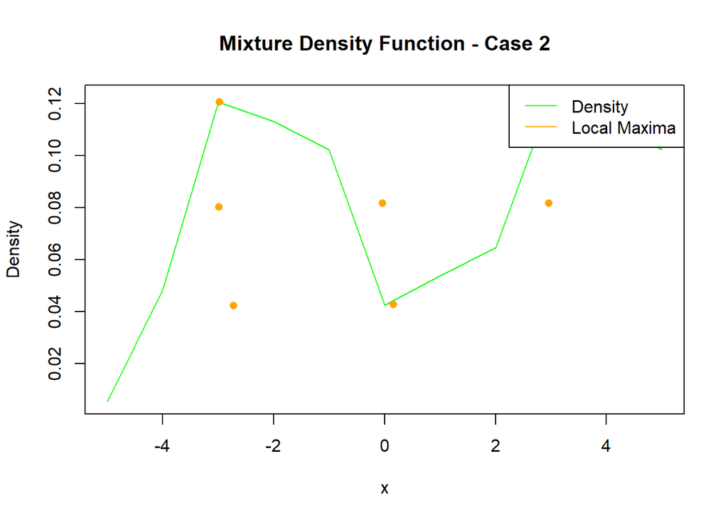

```r
plot(x2, density2, type = "l", col = "green", xlab = "x", ylab = "Density", main = "Mixture Density Function - Case 2")
points(estimated_mode2, dmix(estimated_mode2, mu2, p2), col = "orange", pch = 16)
legend("topright", legend = c("Density", "Local Maxima"), col = c("green", "orange"), lty = 1)
```

### Question 3

```r
wine_data <- scan("C:/Users/tejas/Downloads/wine.txt")
head(wine_data)
```

```
## [1] 127 100 101 113 118 112
```

1. Use function optim() with method “Nelder-Mead” to find the maximum likelihood esti- mate for (μ, σ, α), for the wine data set.

```r
skew_normal_density <- function(x, mu, sigma, alpha) {
  phi <- dnorm((x - mu) / sigma)
  Phi <- pnorm(alpha * (x - mu) / sigma)
  density <- (2 / sigma) * phi * Phi
  density[x - mu > 0 & is.nan(density)] <- -Inf
  return(density)
}

# Define the negative log-likelihood function
skew_normal_neg_log_likelihood <- function(params, x) {
  mu <- params[1]
  sigma <- params[2]
  alpha <- params[3]

  density <- skew_normal_density(x, mu, sigma, alpha)

  neg_log_likelihood <- -sum(log(density))
  if(is.nan(neg_log_likelihood))
    return (-Inf)
  else
  return(neg_log_likelihood)
}

mu_initial <- mean(wine_data)
sigma_initial <- sd(wine_data)
alpha_initial <- 1
initial_params <- c(mu_initial, sigma_initial, alpha_initial)

result <- optim(initial_params, skew_normal_neg_log_likelihood, x = wine_data, method = "Nelder-Mead", control = list(fnscale = -1))

mu_mle_a <- result$par[1]
sigma_mle_a <- result$par[2]
alpha_mle_a <- result$par[3]

result
```

```
## $par
## [1] 1.304356e+14 5.387521e+13 1.549475e+01
##
## $value
## [1] 132263.6
##
## $counts
## function gradient
##      436       NA
##
## $convergence
## [1] 0
##
## $message
## NULL
```

2. Use function optim() with method “BFGS” to find the maximum likelihood estimate for (μ, σ, α), for the wine data set. Since method “BFGS” requires reasonably good initial values, you need to perform a search for the initial values over a grid that covers a sufficiently wide range which includes the MLE found in Part (a)

```r
mu_range <- seq(min(wine_data), max(wine_data), length.out = 20)
sigma_range <- seq(sd(wine_data) - 6, sd(wine_data) + 6, length = 10)
alpha_range <- seq(1, 2, length.out = 20)

best_neg_log_likelihood <- Inf
best_initial_params <- NULL

perform_bfgs_optimization <- function(initial_params, x) {
   result <- optim(initial_params, skew_normal_neg_log_likelihood, x = x, method = "BFGS")
   return(result$par)
 }

for (mu_init in mu_range) {
   for (sigma_init in sigma_range) {
       for (alpha_init in alpha_range) {
           initial_params <- c(mu_init, sigma_init, alpha_init)
            optimized_params <- perform_bfgs_optimization(initial_params, x = wine_data)

             neg_log_likelihood <- skew_normal_neg_log_likelihood(optimized_params, x = wine_data)
              if (neg_log_likelihood < best_neg_log_likelihood) {
                  best_neg_log_likelihood <- neg_log_likelihood
                 best_initial_params <- optimized_params
              }
           }
     }
}
```

[output not shown]

[output cut: 7368 more lines]

[output not shown]

```r
mu_mle_b <- best_initial_params[1]
sigma_mle_b <- best_initial_params[2]
alpha_mle_b <- best_initial_params[3]

best_initial_params
```

```
## [1] 82.469324 22.386914  4.457377
```

3. Produce a histogram as a density for the wine data, with breaks=50, and superimpose it with two density curves: one corresponding to the MLE obtained in Part (a) or (b), and the other to the normal density obtained by maximum likelihood (i.e., when α = 0). The density curves should be distinct in line types and colours

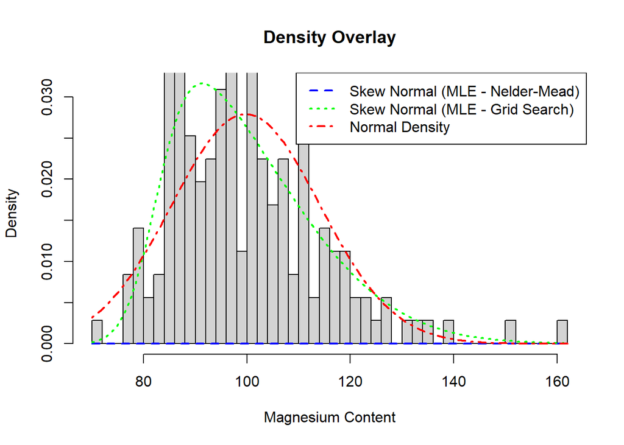

```r
x_vals <- seq(min(wine_data), max(wine_data), length.out = 100)
skew_normal_density_vals_a <- skew_normal_density(x_vals, mu_mle_a, sigma_mle_a, alpha_mle_a)
skew_normal_density_vals_b <- skew_normal_density(x_vals, mu_mle_b, sigma_mle_b, alpha_mle_b)
normal_density_vals <- dnorm(x_vals, mean = mean(wine_data), sd = sd(wine_data))

# Calculate y-axis limits
y_limits <- c(0, max(max(skew_normal_density_vals_a), max(skew_normal_density_vals_b), max(normal_density_vals)))

# Create histogram with probability densities
hist(wine_data, breaks = 50, prob = TRUE, xlim = c(min(wine_data), max(wine_data)),
     ylim = y_limits, xlab = "Magnesium Content", ylab = "Density", main = "Density Overlay")
lines(x_vals, skew_normal_density_vals_a, col = "blue", lty = 2, lwd = 2)
lines(x_vals, skew_normal_density_vals_b, col = "green", lty = 3, lwd = 2)
lines(x_vals, normal_density_vals, col = "red", lty = 4, lwd = 2)

# Add legend
legend("topright", legend = c("Skew Normal (MLE - Nelder-Mead)", "Skew Normal (MLE - Grid Search)", "Normal Density"),
       col = c("blue", "green", "red"), lty = c(2, 3, 4), lwd = 2)
```

4. Produce a contour plot that shows the profile log-likelihood of (μ, α), with σ fixed at its MLE. The MLE for (μ, α) needs to be clearly shown in the plot.

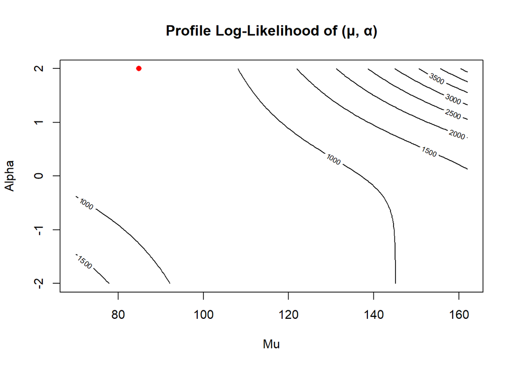

```r
sigma_mle <- best_initial_params[2]

# Define the log-likelihood function for profiling (μ, α)
profile_log_likelihood <- function(mu, alpha, x) {
  neg_log_likelihood <- skew_normal_neg_log_likelihood(c(mu, sigma_mle, alpha), x)
  return(neg_log_likelihood)
}

# Create a grid of mu and alpha values
mu_range <- seq(min(wine_data), max(wine_data), length.out = 100)
alpha_range <- seq(-2, 2, length.out = 100)
mu_alpha_grid <- expand.grid(mu = mu_range, alpha = alpha_range)

# Calculate profile log-likelihood values for the grid
profile_log_likelihood_values <- matrix(NA, nrow = length(mu_range), ncol = length(alpha_range))
for (i in 1:length(mu_range)) {
  for (j in 1:length(alpha_range)) {
    profile_log_likelihood_values[i, j] <- profile_log_likelihood(mu_range[i], alpha_range[j], wine_data)
  }
}

# Create the contour plot
contour(mu_range, alpha_range, profile_log_likelihood_values,
        xlab = "Mu", ylab = "Alpha", main = "Profile Log-Likelihood of (μ, α)")

# Find the MLE for (μ, α)
mle_indices <- which(profile_log_likelihood_values == min(profile_log_likelihood_values), arr.ind = TRUE)
mu_mle_profile <- mu_range[mle_indices[, 1]]
alpha_mle_profile <- alpha_range[mle_indices[, 2]]

# Highlight the MLE point
points(mu_mle_profile, alpha_mle_profile, col = "red", pch = 16)
```